# Reproducible Research: Assignment Week 1

```r
library(knitr)
library("lattice")
```

# 1 Import Data

I imported the following data that was uploaded from the following [location](https://d396qusza40orc.cloudfront.net/repdata%2Fdata%2Factivity.zip) on February 9th, 2016.

```r
raw_data <- read.csv("activity.csv")
#View(activity)
```

# 2 What is mean total number of steps taken per day?

As per the assignment, the missing values can be ignored … *“For this part of the assignment, you can ignore the missing values in the dataset.”*

```r
##Resulting data set below excludes missing data
data_for_this_section = raw_data[complete.cases(raw_data),]
```

## 2.1 Calculate the total number of steps taken per day

```r
##Calculate summation by grouping by date
data_=with(data_for_this_section , aggregate(steps , by=list(Date=date) , FUN=sum ) )
##Rename column to reflect data within
colnames(data_)[2]="TotalNumberOfStep"
##Create table
kable( data_ )
```

| Date | TotalNumberOfStep |
| --- | --- |
| 2012-10-02 | 126 |
| 2012-10-03 | 11352 |
| 2012-10-04 | 12116 |
| 2012-10-05 | 13294 |
| 2012-10-06 | 15420 |
| 2012-10-07 | 11015 |
| 2012-10-09 | 12811 |
| 2012-10-10 | 9900 |
| 2012-10-11 | 10304 |
| 2012-10-12 | 17382 |
| 2012-10-13 | 12426 |
| 2012-10-14 | 15098 |
| 2012-10-15 | 10139 |
| 2012-10-16 | 15084 |
| 2012-10-17 | 13452 |
| 2012-10-18 | 10056 |
| 2012-10-19 | 11829 |
| 2012-10-20 | 10395 |
| 2012-10-21 | 8821 |
| 2012-10-22 | 13460 |
| 2012-10-23 | 8918 |
| 2012-10-24 | 8355 |
| 2012-10-25 | 2492 |
| 2012-10-26 | 6778 |
| 2012-10-27 | 10119 |
| 2012-10-28 | 11458 |
| 2012-10-29 | 5018 |
| 2012-10-30 | 9819 |
| 2012-10-31 | 15414 |
| 2012-11-02 | 10600 |
| 2012-11-03 | 10571 |
| 2012-11-05 | 10439 |
| 2012-11-06 | 8334 |
| 2012-11-07 | 12883 |
| 2012-11-08 | 3219 |
| 2012-11-11 | 12608 |
| 2012-11-12 | 10765 |
| 2012-11-13 | 7336 |
| 2012-11-15 | 41 |
| 2012-11-16 | 5441 |
| 2012-11-17 | 14339 |
| 2012-11-18 | 15110 |
| 2012-11-19 | 8841 |
| 2012-11-20 | 4472 |
| 2012-11-21 | 12787 |
| 2012-11-22 | 20427 |
| 2012-11-23 | 21194 |
| 2012-11-24 | 14478 |
| 2012-11-25 | 11834 |
| 2012-11-26 | 11162 |
| 2012-11-27 | 13646 |
| 2012-11-28 | 10183 |
| 2012-11-29 | 7047 |

## 2.2 Make a histogram of the total number of steps taken each day

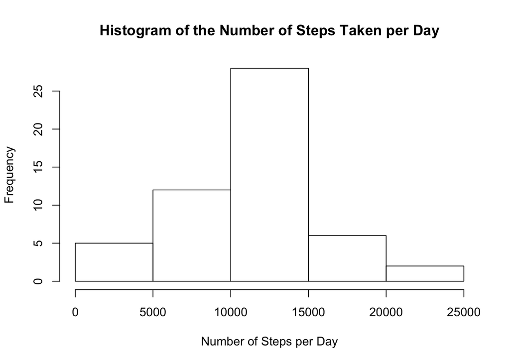

```r
##create histogram of TotalNumberOfStep = data_[,2]
hist( data_[,2] , xlab = "Number of Steps per Day" , main = "Histogram of the Number of Steps Taken per Day" )
```

## 2.3 Calculate and report the mean and median of the total number of steps taken per day

### 2.3.1 Mean of the total number of steps taken per day

```r
##set numeric resolution to two decimals. Makes data pretty and prevents scientifics
options(scipen=2)
##calculate means
MeanValue=mean(data_[,2])
##print statement that incorporates the answer to question
print(paste0("The **mean value** of the total number of steps taken each day is ", MeanValue , " ."))
```

```
## [1] "The **mean value** of the total number of steps taken each day is 10766.1886792453 ."
```

The **mean value** of the total number of steps taken each day is 10766.1886792.

### 2.3.2 Median of the total number of steps taken per day

```r
##calculate median
MedianValue=median(data_[,2])
print(paste0("The **median value** of the total number of steps taken each day is ", MedianValue , " ."))
```

```
## [1] "The **median value** of the total number of steps taken each day is 10765 ."
```

The **median value** of the total number of steps taken each day is 10765.

# 3 What is the average daily activity pattern?

## 3.1 Make a time series plot (i.e. 𝚝𝚢𝚙𝚎 = “𝚕”) of the 5-minute interval (x-axis) and the average number of steps taken, averaged across all days (y-axis)

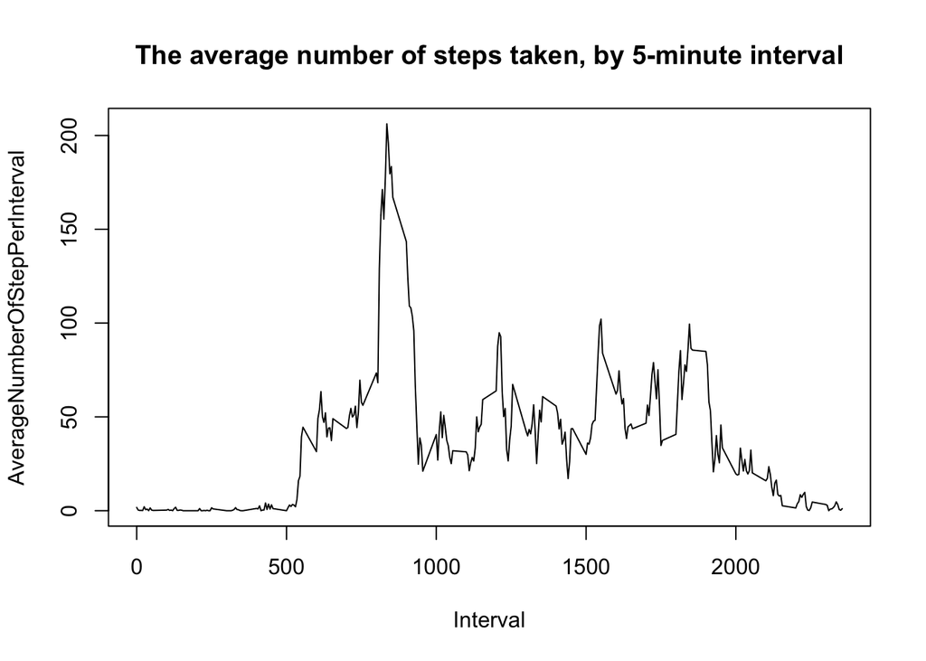

```r
##work will complete (non-na) data
data_for_this_section = raw_data[complete.cases(raw_data),]
##Calculate means by interval
data_=with(data_for_this_section , aggregate(steps , by=list(Interval=interval) , FUN=mean ) )
colnames(data_)[2]="AverageNumberOfStepPerInterval"
#data_for_this_section = subset(data_for_this_section , interval==5 )
with(data_ , plot( Interval , AverageNumberOfStepPerInterval , type="l" , main=("The average number of steps taken, by 5-minute interval") ) )
```

## 3.2 Which 5-minute interval, on average across all the days in the dataset, contains the maximum number of steps?

```r
#sort by Average Step Interval descending
data2_=head(data_[order(-data_$AverageNumberOfStepPerInterval),] , n=1 )
#create table
kable(data2_)
```

|  | Interval | AverageNumberOfStepPerInterval |
| --- | --- | --- |
| 104 | 835 | 206.1698 |

```r
#print statement
print(paste0("The following interval **",data2_$Interval, "** has the maximum number of steps, whose average across all days is **", data2_$AverageNumberOfStepPerInterval ,"** ."))
```

```
## [1] "The following interval **835** has the maximum number of steps, whose average across all days is **206.169811320755** ."
```

The following interval **835** has the maximum number of steps, whose average across all days is **206.1698113** .

# 4 Imputing missing values

## 4.1 Calculate and report the total number of missing values in the dataset (i.e. the total number of rows with 𝙽𝙰s)

```r
#create incomplete table
data_with_na = raw_data[!complete.cases(raw_data),]
#print statement
print(paste0("The number of missing values is the dataset is  **",nrow(data_with_na), "**."))
```

```
## [1] "The number of missing values is the dataset is  **2304**."
```

The number of missing values is the dataset is **2304** .

## 4.2 Devise a strategy for filling in all of the missing values in the dataset. The strategy does not need to be sophisticated. For example, you could use the mean/median for that day, or the mean for that 5-minute interval, etc.

The strategy I deviced was to use the median value of the existing data at the interval, to fill up the missing data.

```r
#create complete table
data_complete = raw_data[complete.cases(raw_data),]
#calculate median by interval from complete data
data_median =with(data_complete , aggregate(steps , by=list(Interval=interval) , FUN=median ) )
#merge incomplete data with median data
data_merge=merge(x=data_with_na , y=data_median , by.x="interval" , by.y="Interval" , all=FALSE )
#set incomplete(na) steps as equal median
data_merge$steps=data_merge$x
```

## 4.3 Create a new dataset that is equal to the original dataset but with the missing data filled in.

```r
#create table with imputted data
data_merge=data_merge[,1:3]
#merge complete data with imputted data
data_imput=rbind(data_complete, data_merge )
```

## 4.4 Make a histogram of the total number of steps taken each day with imputted data

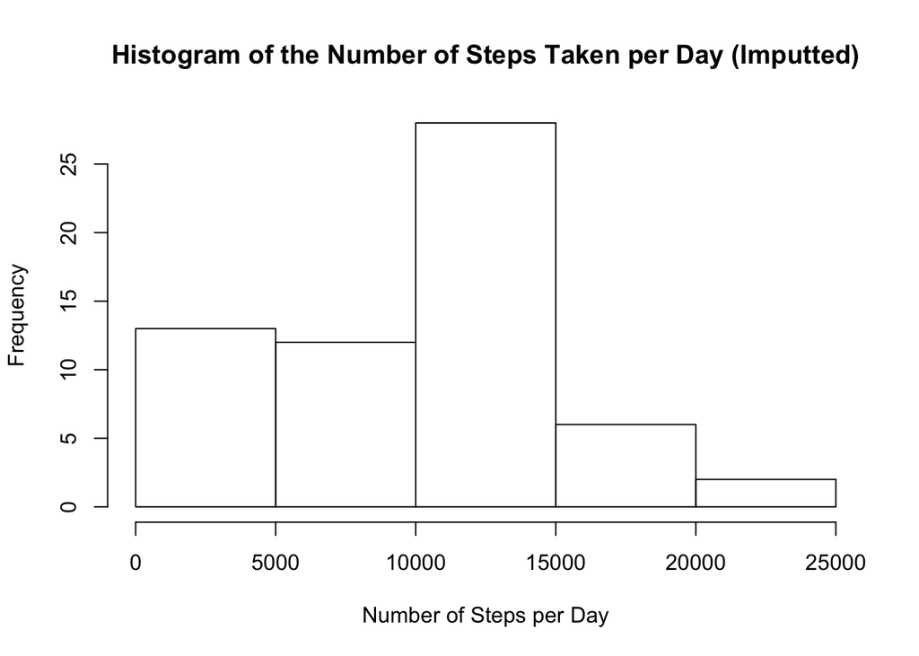

```r
#sum by date of complete imputted data
data_=with( data_imput , aggregate(steps , by=list(Date=date) , FUN=sum ) )
colnames(data_)[2]="TotalNumberOfStep"
#create histogram
hist( data_[,2] , xlab = "Number of Steps per Day" , main = "Histogram of the Number of Steps Taken per Day (Imputted)" )
```

## 4.5 Calculate and report the mean total number of steps taken per day with imputted data

```r
##set numeric resolution to two decimals. Makes data pretty and prevents scientifics
options(scipen=2)
MeanValue_imput=mean(data_[,2])
print(paste0("The **mean value** of the total number of steps taken each day is ", MeanValue_imput , " ."))
```

```
## [1] "The **mean value** of the total number of steps taken each day is 9503.86885245902 ."
```

The **mean value** of the total number of steps taken each day is 9503.8688525.

## 4.6 Calculate and report the median total number of steps taken per day with imputted data

```r
MedianValue_imput=median(data_[,2])
print(paste0("The **median value** of the total number of steps taken each day is ", MedianValue_imput , " ."))
```

```
## [1] "The **median value** of the total number of steps taken each day is 10395 ."
```

The **median value** of the total number of steps taken each day is 10395.

## 4.7 Do these values differ from the estimates from the first part of the assignment?

### 4.7.1 means

Yes they do differ.

Before imputting the mean was 10766.1886792. After imputting, the mean value is 9503.8688525

### 4.7.2 median

Yes they do differ.

Before imputting the median was 10765. After imputting, the median value is 10395

## 4.8 What is the impact of imputing missing data on the estimates of the total daily number of steps?

Based on the method that I selected i.e. using the median to imput missing values, both the mean value and the median value seem to decrease.

# 5 Are there differences in activity patterns between weekdays and weekends?

## 5.1 Create a new factor variable in the dataset with two levels – “weekday” and “weekend” indicating whether a given date is a weekday or weekend day.

```r
#logic to determine if a day is a weekend or a weekday.
data_imput$Weekend=ifelse(weekdays( as.Date(data_imput$date) )=="Saturday" | weekdays( as.Date(data_imput$date) )=="Sunday" , "Weekend" , "Weekday")
##validation code below to confirm that the above procedure is correct
#unique(paste ( weekdays( as.Date(data_imput$date) ) , data_imput$Weekend))
```

## 5.2 Make a panel plot containing a time series plot (i.e. 𝚝𝚢𝚙𝚎 = “𝚕”) of the 5-minute interval (x-axis) and the average number of steps taken, averaged across all weekday days or weekend days (y-axis).

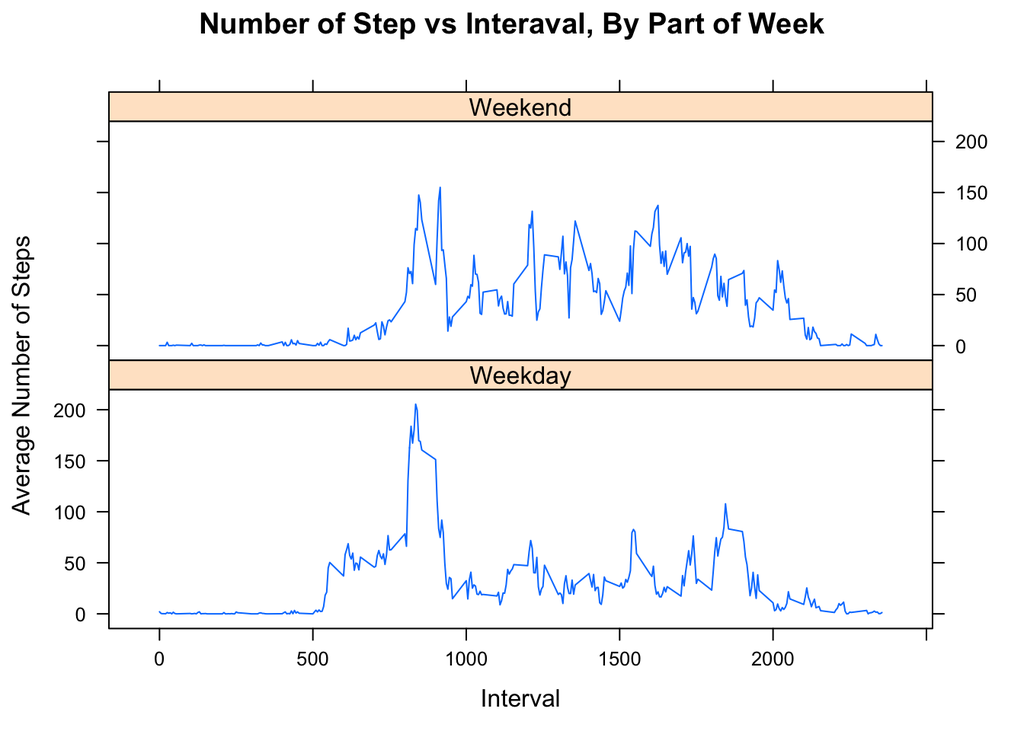

```r
#calculate mean by Weekend and interval
data_=with( data_imput , aggregate(steps , by=list(Weekend, interval) , FUN=mean ) )
colnames(data_)[1]="PartOfWeek"
colnames(data_)[2]="Interval"
colnames(data_)[3]="AverageNumberOfSteps"
#create plot
xyplot(AverageNumberOfSteps ~ Interval | factor(PartOfWeek), data=data_, pch=19,main="Number of Step vs Interaval, By Part of Week", xlab="Interval",  ylab="Average Number of Steps",layout=c(1,2), type="l" )
```